# Course 8 Assignment

Andrew Lau

7 October 2018

# Step 0 - Loading libraries

```r
library(lattice)
library(ggplot2)
library(caret)
library(ggplot2)
library(RANN)
library(e1071)
```

# Step 1 - Import data and pre-processing

The first 7 columns are not useful for predicting and have thus been removed.

```r
setwd("C:/Users/AndreL01/Documents/JHU data science/Assignment")
train <- read.csv("pml-training.csv")
test <- read.csv("pml-testing.csv")

#check structure of data
# str(train)
# str(test)

#removing nonsensical predictors
train$X <- NULL
train$user_name <- NULL
train$raw_timestamp_part_1 <- NULL
train$raw_timestamp_part_2 <- NULL
train$cvtd_timestamp <- NULL
train$new_window <- NULL
train$num_window <- NULL

test$X <- NULL
test$user_name <- NULL
test$raw_timestamp_part_1 <- NULL
test$raw_timestamp_part_2 <- NULL
test$cvtd_timestamp <- NULL
test$new_window <- NULL
test$num_window <- NULL
```

# Step 2 - Exploratory Data Analysis and data pre-processing

Data exploration is performed to get a better feel of what the data is and how it is structured.

- Check distribution amongst classes
- Check classes of each column
- Convert predictors that are clearly meant to be numeric from factor to numeric
- The classes of each column in the train and test set are different
- remove factors with near zero variance

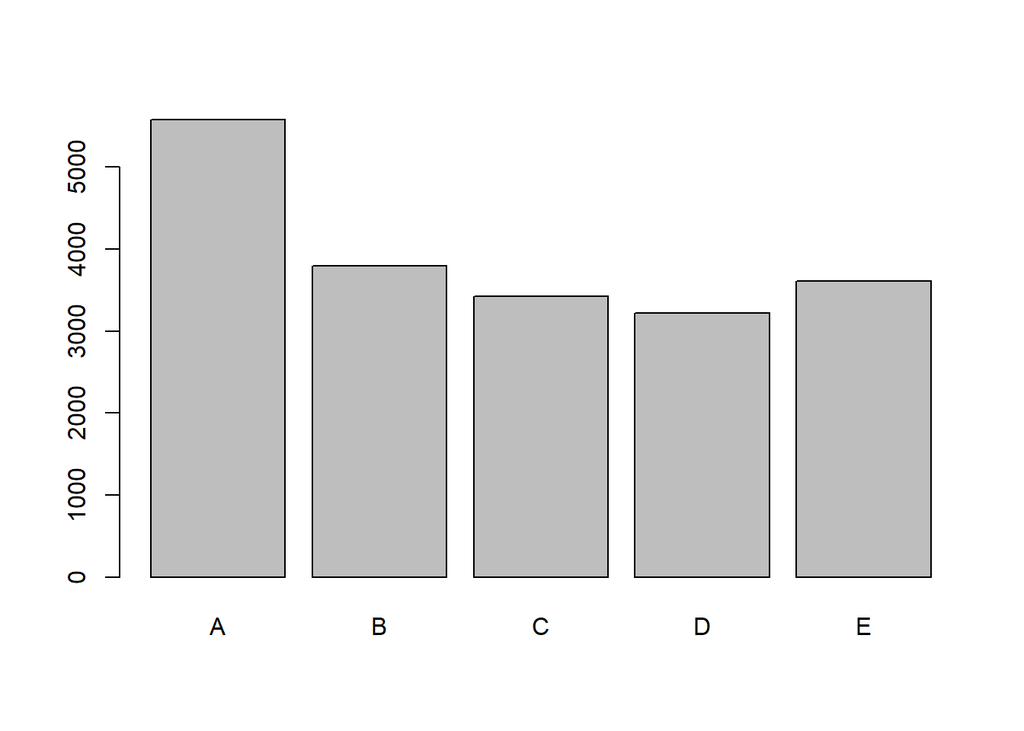

```r
trainPP <- train
testPP <- test

#split amongst classes
barplot(table(trainPP$classe))
```

```r
#check each column's class
# sapply(trainPP,class)
# sapply(testPP,class)

#there seems to be numeric saved as factors
#converting factors with more than 25 levels to numeric
for(i in names(trainPP)){
    if(class(trainPP[[i]]) == "factor"){
        if(length(levels(trainPP[[i]])) > 25){
            trainPP[[i]] <- as.numeric(as.character(trainPP[[i]]))
            testPP[[i]] <- as.numeric(as.character(testPP[[i]]))
        }
    }
}
#make all classes in test same as train
#test set has logical of all NA's, convert to numeric
for(i in 1:dim(testPP)[2]){
    if(class(testPP[,i]) == "logical" & all(is.na(testPP[,i]))){
            testPP[,i] <- as.numeric(rep(NA,dim(testPP)[1]))
    }
}
#convert all classes in test to match train
for(i in 1:dim(trainPP)[2]){
    if(class(trainPP[, i]) == "factor"){
        testPP[, i] <- as.factor(testPP[, i])
    }
    else{
        class(testPP[, i]) <- class(trainPP[, i])
    }
}

#check classes in trainPP and testPP match
# sapply(trainPP,class)
# sapply(testPP,class)

#removing near zero variance factors
nzv <- nearZeroVar(trainPP)
trainPP <- trainPP[, -nzv]
testPP <- testPP[, -nzv]

#final dimensions of the data
dim(testPP)
```

```
## [1]  20 118
```

```r
dim(trainPP)
```

```
## [1] 19622   118
```

```r
# str(trainPP
#     , list.len = dim(trainPP)[2]
#     )
# str(testPP
#     , list.len = dim(testPP)[2]
#     )
```

# step 4 - Data Splitting

Have split training dataset into a trainTrain and trainValid set.

```r
set.seed(1234)
trainIndex <- createDataPartition(train$classe, p = .6,
                                  list = FALSE,
                                  times = 1)
trainTrain <- train[ trainIndex,]
trainValid  <- train[-trainIndex,]

trainPPTrain <- trainPP[ trainIndex,]
trainPPValid  <- trainPP[-trainIndex,]
```

# Step 5 - modelling

6-fold cross-validation is used here to estimate the out-of-sample error. Introduction to Statistical Learning recommends between 6 and 10 folds.

```r
fitControl <- trainControl(## 10-fold CV
                           method = "repeatedcv"
                           ,number = 6
                           ## repeated ten times
                           ,repeats = 1
                            )
```

## Step 5a - LDA

```r
set.seed(825)

ldaFit1 <- train(classe ~ ., data = trainPPTrain[,colSums(is.na(trainPPTrain))==0]
                 ,method = "lda"
                 ,trControl = fitControl
                 ,na.action = na.pass
                 )
varImp(ldaFit1)
```

```
## ROC curve variable importance
##
##   variables are sorted by maximum importance across the classes
##   only 20 most important variables shown (out of 52)
##
##                        A       B     C      D       E
## pitch_forearm     62.769 100.000 68.12 62.769 100.000
## accel_forearm_x   37.049  78.099 37.05 37.049  78.099
## magnet_arm_x      52.085  74.796 63.66 52.085  74.796
## magnet_arm_y      38.461  72.388 66.31 38.461  72.388
## pitch_dumbbell    51.455  51.455 51.45 69.853  41.043
## accel_arm_x       50.210  69.495 60.67 50.210  69.495
## magnet_forearm_x  37.144  69.015 32.20 32.201  69.015
## magnet_belt_y     15.122   7.486 68.74 11.264  15.122
## magnet_dumbbell_y 47.866  47.866 47.87 67.403  47.220
## magnet_dumbbell_x 66.482  66.482 66.48 66.482  50.196
## roll_dumbbell     42.807  51.919 30.12 62.971  51.919
## accel_dumbbell_x  55.579  55.579 55.58 56.545  45.554
## magnet_belt_z      2.016   4.966 54.40  1.973   4.966
## magnet_dumbbell_z 54.023  35.724 52.72 23.167  54.023
## magnet_arm_z      53.491  53.491 53.49 53.491  38.500
## pitch_arm         29.664  41.666 50.21 29.664  41.666
## roll_belt         10.334   5.579 46.67  6.976  10.334
## yaw_dumbbell      20.438  20.438 20.44 42.168  14.078
## accel_dumbbell_y  36.177  17.117 17.12 42.078  36.177
## accel_dumbbell_z  41.309  41.309 41.31 41.309  15.817
```

```r
#prediction on validation
ldaPredict1_trainPPValid <- predict(ldaFit1, newdata = trainPPValid, na.action=na.pass)
#prediction on test
ldaPredict1_testPP <- predict(ldaFit1, newdata = testPP, na.action=na.pass)

#accuracy on trainTrain
ldaFit1
```

```
## Linear Discriminant Analysis
##
## 11776 samples
##    52 predictor
##     5 classes: 'A', 'B', 'C', 'D', 'E'
##
## No pre-processing
## Resampling: Cross-Validated (6 fold, repeated 1 times)
## Summary of sample sizes: 9815, 9814, 9812, 9813, 9813, 9813, ...
## Resampling results:
##
##   Accuracy   Kappa
##   0.7025301  0.6233695
```

```r
#accuracy on trainValid
confusionMatrix(data=ldaPredict1_trainPPValid,reference = trainPPValid$classe)$overall[1]
```

```
##  Accuracy
## 0.7020138
```

The LDA produces a model with an accuracy of about 70% on both the training and validation data sets. Cross-validation is providing a decent estimate of the validation error. LDA here is not the best model.

## Step 5b - Decision Tree

We begin by fitting a simple decision tree

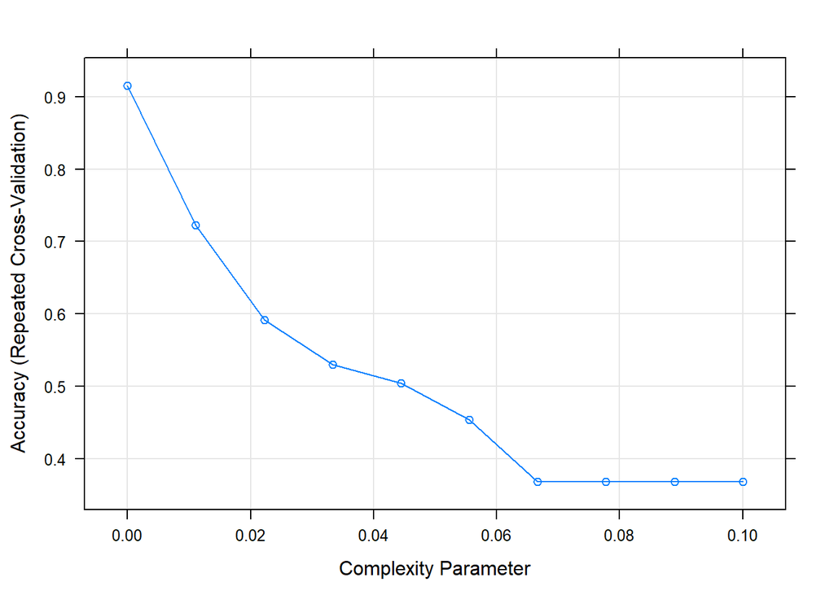

```r
treeGrid <-  expand.grid(cp = seq(from=0.0000000000000000000000000000000000001, to=0.1, length.out = 10)
                         )
set.seed(78)
treeFit1 <- train(classe ~ ., data = trainPPTrain
                 ,method = "rpart"
                 ,tuneGrid = treeGrid
                 ,trControl = fitControl
                 ,na.action = na.pass
                 # ,preProcess = c("knnImpute")
                 )
#hyperparameters
plot(treeFit1)
```

```r
#variable importance
varImp(treeFit1)
```

```
## rpart variable importance
##
##   only 20 most important variables shown (out of 117)
##
##                   Overall
## roll_belt          100.00
## yaw_belt            84.90
## pitch_forearm       81.45
## pitch_belt          73.30
## roll_forearm        69.99
## accel_dumbbell_y    63.60
## magnet_dumbbell_z   62.82
## magnet_dumbbell_y   53.39
## roll_dumbbell       47.57
## magnet_forearm_z    38.69
## magnet_belt_z       37.97
## yaw_arm             36.64
## magnet_dumbbell_x   36.42
## accel_belt_z        34.59
## accel_dumbbell_z    33.68
## magnet_belt_y       33.68
## accel_forearm_x     32.28
## accel_arm_x         27.79
## magnet_forearm_y    27.13
## gyros_belt_z        24.08
```

```r
#prediction on validation
treePredict1_trainPPValid <- predict(treeFit1, newdata = trainPPValid, na.action=na.pass)
#prediction on test
treePredict1_testPP <- predict(treeFit1, newdata = testPP, na.action=na.pass)

#accuracy on trainTrain
treeFit1
```

```
## CART
##
## 11776 samples
##   117 predictor
##     5 classes: 'A', 'B', 'C', 'D', 'E'
##
## No pre-processing
## Resampling: Cross-Validated (6 fold, repeated 1 times)
## Summary of sample sizes: 9814, 9813, 9813, 9812, 9814, 9814, ...
## Resampling results across tuning parameters:
##
##   cp            Accuracy   Kappa
##   1.000000e-37  0.9155901  0.8932205
##   1.111111e-02  0.7225744  0.6493470
##   2.222222e-02  0.5915400  0.4795246
##   3.333333e-02  0.5295542  0.3924347
##   4.444444e-02  0.5039913  0.3586148
##   5.555556e-02  0.4533767  0.2705709
##   6.666667e-02  0.3676967  0.1269362
##   7.777778e-02  0.3676967  0.1269362
##   8.888889e-02  0.3676967  0.1269362
##   1.000000e-01  0.3676967  0.1269362
##
## Accuracy was used to select the optimal model using the largest value.
## The final value used for the model was cp = 1e-37.
```

```r
#accuracy on trainValid
confusionMatrix(data=treePredict1_trainPPValid,reference = trainPPValid$classe)$overall[1]
```

```
##  Accuracy
## 0.9219985
```

Decision trees give an accuracy of around 92% on both the training and validation set which is an improvement over the LDA model.

## Step 5c - Random Forest

Random forest can improve upon decision trees by bootstrapping and aggregating (bagging) many decision trees which decreases the varaince of predictions and hence overall error. N predictors are chosen at random with each decision tree to “decorrelate” the decision trees and hence reduce the variance further. Let’s see how it performs versus the decision tree fit above.

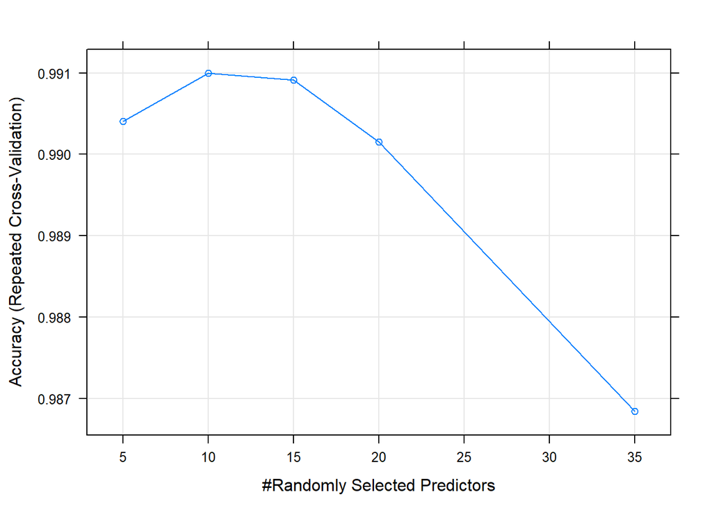

```r
rforestGrid <-  expand.grid(mtry = c(5,10,15,20,35)
                         )

set.seed(934)

#random forest doesn't work with NA predictors, removed those columns
rforestFit1 <- train(classe ~ ., data = trainPPTrain[,colSums(is.na(trainPPTrain))==0]
                 ,method = "rf"
                 ,tuneGrid = rforestGrid
                 ,trControl = fitControl
                 ,na.action = na.pass
                 )
#hyperparameters
plot(rforestFit1)
```

```r
#variable importance
varImp(rforestFit1)
```

```
## rf variable importance
##
##   only 20 most important variables shown (out of 52)
##
##                      Overall
## roll_belt             100.00
## yaw_belt               67.36
## pitch_forearm          61.20
## magnet_dumbbell_z      52.65
## magnet_dumbbell_y      51.04
## pitch_belt             50.48
## roll_forearm           42.76
## magnet_dumbbell_x      30.76
## accel_dumbbell_y       27.17
## magnet_belt_z          27.02
## roll_dumbbell          26.50
## accel_belt_z           24.10
## magnet_belt_y          23.96
## accel_dumbbell_z       19.84
## roll_arm               19.10
## accel_forearm_x        18.17
## magnet_forearm_z       16.71
## gyros_belt_z           15.73
## total_accel_dumbbell   15.28
## magnet_belt_x          14.14
```

```r
#prediction on validation
rforestPredict1_trainPPValid <- predict(rforestFit1, newdata = trainPPValid, na.action=na.pass)
#prediction on test
rforestPredict1_testPP <- predict(rforestFit1, newdata = testPP, na.action=na.pass)

#accuracy on trainTrain
rforestFit1
```

```
## Random Forest
##
## 11776 samples
##    52 predictor
##     5 classes: 'A', 'B', 'C', 'D', 'E'
##
## No pre-processing
## Resampling: Cross-Validated (6 fold, repeated 1 times)
## Summary of sample sizes: 9812, 9815, 9814, 9813, 9814, 9812, ...
## Resampling results across tuning parameters:
##
##   mtry  Accuracy   Kappa
##    5    0.9904047  0.9878605
##   10    0.9909993  0.9886131
##   15    0.9909144  0.9885057
##   20    0.9901497  0.9875381
##   35    0.9868385  0.9833490
##
## Accuracy was used to select the optimal model using the largest value.
## The final value used for the model was mtry = 10.
```

```r
#accuracy on trainValid
confusionMatrix(data=rforestPredict1_trainPPValid,reference = trainPPValid$classe)$overall[1]
```

```
##  Accuracy
## 0.9929901
```

We are getting accuracies of 99% on our training and validation test sets using the Random Forest. This is pretty good but let’s throw a GBM at it and see how it runs.

## 5d GBM

```r
fitControl <- trainControl(## 10-fold CV
                           method = "repeatedcv"
                           ,number = 3
                           ## repeated ten times
                           ,repeats = 1
                            )
gbmGrid <-  expand.grid(interaction.depth = c(6,8),
                        n.trees = 2000,
                        shrinkage = 0.01,
                        n.minobsinnode = c(ceiling(0.025*dim(train)[1]),ceiling(0.05*dim(train)[1])))

set.seed(825)
gbmFit1 <- train(classe ~ ., data = trainPPTrain
                 ,method = "gbm"
                 ,tuneGrid = gbmGrid
                 ,trControl = fitControl
                 ,bag.fraction = 0.7
                 ,verbose = TRUE
                 ,na.action = na.pass
                 )
```

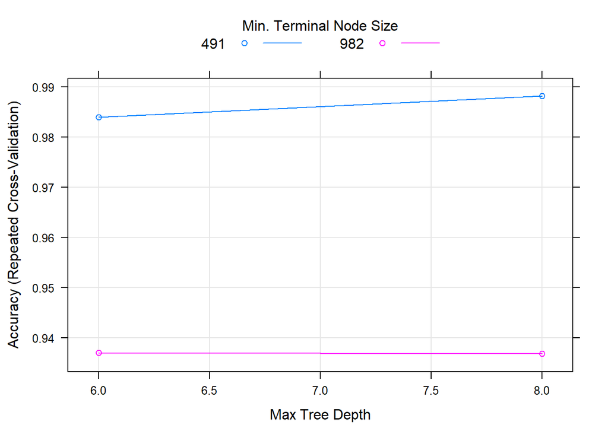

```r
#hyperparameters
plot(gbmFit1)
```

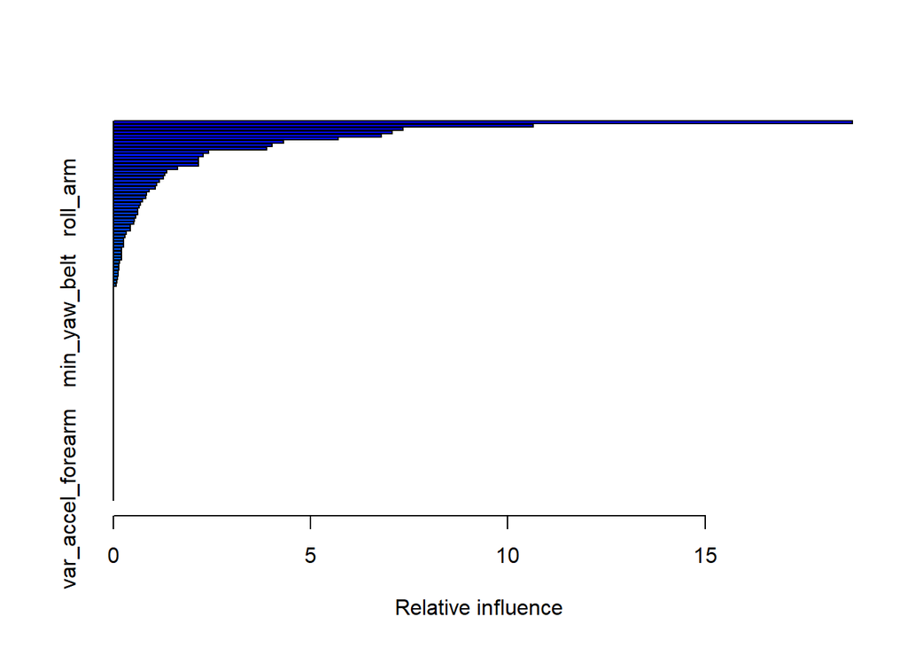

```
##                                               var      rel.inf
## roll_belt                               roll_belt 18.731591628
## pitch_forearm                       pitch_forearm 10.645790693
## yaw_belt                                 yaw_belt  7.334774497
## magnet_dumbbell_y               magnet_dumbbell_y  7.063556703
## magnet_dumbbell_z               magnet_dumbbell_z  6.797672660
## roll_forearm                         roll_forearm  5.701577909
## pitch_belt                             pitch_belt  4.315404890
## magnet_belt_z                       magnet_belt_z  4.017797261
## roll_dumbbell                       roll_dumbbell  3.885847034
## gyros_dumbbell_y                 gyros_dumbbell_y  2.408136621
## magnet_dumbbell_x               magnet_dumbbell_x  2.278606442
## accel_forearm_x                   accel_forearm_x  2.161399286
## accel_dumbbell_z                 accel_dumbbell_z  2.160752240
## accel_dumbbell_y                 accel_dumbbell_y  2.155693485
## gyros_belt_z                         gyros_belt_z  1.633800344
## accel_forearm_z                   accel_forearm_z  1.357916879
## magnet_belt_x                       magnet_belt_x  1.305094427
## magnet_forearm_z                 magnet_forearm_z  1.271079951
## magnet_arm_z                         magnet_arm_z  1.157214433
## magnet_belt_y                       magnet_belt_y  1.092966370
## yaw_arm                                   yaw_arm  1.055926795
## magnet_arm_y                         magnet_arm_y  0.908927000
## accel_belt_z                         accel_belt_z  0.832287273
## roll_arm                                 roll_arm  0.824837617
## accel_dumbbell_x                 accel_dumbbell_x  0.735970638
## gyros_arm_y                           gyros_arm_y  0.681788111
## total_accel_dumbbell         total_accel_dumbbell  0.652126903
## accel_forearm_y                   accel_forearm_y  0.614423381
## yaw_dumbbell                         yaw_dumbbell  0.612581765
## gyros_dumbbell_x                 gyros_dumbbell_x  0.560448057
## magnet_forearm_y                 magnet_forearm_y  0.526026964
## magnet_forearm_x                 magnet_forearm_x  0.515190227
## accel_arm_x                           accel_arm_x  0.434929783
## magnet_arm_x                         magnet_arm_x  0.425054219
## accel_arm_y                           accel_arm_y  0.334484202
## gyros_forearm_y                   gyros_forearm_y  0.298289652
## pitch_arm                               pitch_arm  0.263295641
## total_accel_forearm           total_accel_forearm  0.255812630
## accel_arm_z                           accel_arm_z  0.252089472
```

[output cut: 63 more lines]

```
## stddev_pitch_dumbbell       stddev_pitch_dumbbell  0.000000000
## var_pitch_dumbbell             var_pitch_dumbbell  0.000000000
## avg_yaw_dumbbell                 avg_yaw_dumbbell  0.000000000
## stddev_yaw_dumbbell           stddev_yaw_dumbbell  0.000000000
## var_yaw_dumbbell                 var_yaw_dumbbell  0.000000000
## kurtosis_roll_forearm       kurtosis_roll_forearm  0.000000000
## kurtosis_picth_forearm     kurtosis_picth_forearm  0.000000000
## skewness_roll_forearm       skewness_roll_forearm  0.000000000
## skewness_pitch_forearm     skewness_pitch_forearm  0.000000000
## max_picth_forearm               max_picth_forearm  0.000000000
## max_yaw_forearm                   max_yaw_forearm  0.000000000
## min_pitch_forearm               min_pitch_forearm  0.000000000
## min_yaw_forearm                   min_yaw_forearm  0.000000000
## amplitude_pitch_forearm   amplitude_pitch_forearm  0.000000000
## var_accel_forearm               var_accel_forearm  0.000000000
```

```r
#variable importance
summary(gbmFit1)
```

```r
#prediction on validation
gbmPredict1_trainPPValid <- predict(gbmFit1, newdata = trainPPValid, na.action=na.pass)
#prediction on test
gbmPredict1_testPP <- predict(gbmFit1, newdata = testPP, na.action=na.pass)

#accuracy on trainTrain
gbmFit1
```

```
## Stochastic Gradient Boosting
##
## 11776 samples
##   117 predictor
##     5 classes: 'A', 'B', 'C', 'D', 'E'
##
## No pre-processing
## Resampling: Cross-Validated (3 fold, repeated 1 times)
## Summary of sample sizes: 7851, 7851, 7850
## Resampling results across tuning parameters:
##
##   interaction.depth  n.minobsinnode  Accuracy   Kappa
##   6                  491             0.9840349  0.9798060
##   6                  982             0.9369901  0.9202779
##   8                  491             0.9881959  0.9850683
##   8                  982             0.9368204  0.9200600
##
## Tuning parameter 'n.trees' was held constant at a value of 2000
##
## Tuning parameter 'shrinkage' was held constant at a value of 0.01
## Accuracy was used to select the optimal model using the largest value.
## The final values used for the model were n.trees = 2000,
##  interaction.depth = 8, shrinkage = 0.01 and n.minobsinnode = 491.
```

```r
#accuracy on trainValid
confusionMatrix(data=gbmPredict1_trainPPValid,reference = trainPPValid$classe)$overall[1]
```

```
##  Accuracy
## 0.9937548
```

# Step 6 - results

For our final model, we would go with the random forest. It’s prediction accuracy is similar to the GBM and takes a lot longer to run.

```r
data.frame("LDA" = ldaPredict1_testPP, "Decision Tree" = treePredict1_testPP
           , "Random Forest" = rforestPredict1_testPP ,"GBM"=gbmPredict1_testPP)
```

```
##    LDA Decision.Tree Random.Forest GBM
## 1    B             B             B   B
## 2    A             A             A   A
## 3    B             B             B   B
## 4    C             A             A   A
## 5    C             A             A   A
## 6    E             D             E   E
## 7    D             D             D   D
## 8    D             A             B   B
## 9    A             A             A   A
## 10   A             A             A   A
## 11   D             B             B   B
## 12   A             C             C   C
## 13   B             B             B   B
## 14   A             A             A   A
## 15   E             E             E   E
## 16   A             E             E   E
## 17   A             A             A   A
## 18   B             B             B   B
## 19   B             B             B   B
## 20   B             B             B   B
```